# Benchmarking: calling cancer cells

2026-08-13

**Runs:** pilot `260423_VH01624_453_222HWMYNX` (HBDN206-MNpCT, HBDN392-AML-MDS, HBDN501-AML-KMT2A, MOLM13) and `260528_VH01624_464_222K7VKNX` / LK2 (normal-01, HBDN376-TP53, HBDN498-TP53, APOP576-TP53).

**Analysis finished:** 2026-08-12 - the most recent of the 49 figures shown below.

**Report generated:** 2026-08-13 by `09.cancer_calling_report.Rmd`, from the outputs of steps 01-08 in this folder.

Which cells in a patient sample are the leukaemia. There is no ground truth, so the question is approached by running two independent CNV callers on the same cells and asking where they agree, running one of them on a healthy donor to measure the false-positive floor, and running the same caller on short-read and long-read sequencing of the same cells to see how much the call depends on the data rather than the method.

For full report, download `cancer_calling_report.html` in the attachment and open in a browser.

Code used - attached and in the github repository: https://github.com/nbartonicek/surface_proteome_dev/tree/main/lab_archives/8.Benchmarking-calling_cancer_cells

# Aim

Establish how malignant cells are identified, and how far the calls can be trusted:

- do two independent CNV callers agree on the same cells, and where do they not
- what does a caller do on a donor with no cancer - the false positive floor
- does the call depend on the sequencing platform
- which populations are hardest to call

# Conclusions

- **CopyKAT and Numbat agree on the great majority of cells** - 96.35% and 94.96% on HBDN206-MNpCT and HBDN501-AML-KMT2A
- **but that headline agreement is inflated and should not be quoted on its own.** It is carried by HSC MPP, which is 4,002 of the 4,409 shared cells in HBDN206-MNpCT and agrees 99.8%. Agreement in the lymphoid compartment is far worse - Naive T 25%, B 51%, CD4 Memory T 63% - and those are exactly the populations handed to CopyKAT as its confident-normal anchor. CopyKAT calls them diploid partly by construction, so the two callers are not independent there
- **where they disagree, it is one-directional: Numbat calls malignant, CopyKAT calls normal** (152 against 9 cells in HBDN206-MNpCT, 73 against 2 in HBDN501-AML-KMT2A). Numbat is the more liberal caller on this data
- **Numbat is specific.** On the healthy donor its CNV evidence sits at a median `cnv_z_abs_mean` of 15.3 against 123-315 in the three AML donors, and only **1.0%** of normal-01 cells exceed the 99th percentile of the normal distribution against **97-100%** of AML cells. Calling cancer where there is none is not the failure mode to worry about
- **the platform changes the answer more than the caller does.** Same cells, same Numbat, short read against long read: compartment concordance is 94.2%, 89.5%, 63.6%, but per-cell pCNV correlation is only 0.19, 0.41, 0.12. So the two platforms sort cells into the same bin reasonably often while disagreeing almost entirely about how much CNV evidence each cell carries
- **that disagreement is also one-directional** - short read calls tumour where long read calls normal (339, 566 and 365 cells) and almost never the reverse (0, 99, 2). Long read is the more conservative platform, which is expected given its much lower depth per cell
- **Numbat did not complete for two of the four pilot donors.** HBDN392-AML-MDS and MOLM13 are 100% `not_called`. Any pilot statement about Numbat rests on two donors
- **MOLM13 is never actually called by either method.** It is an AML cell line with no normal cells to anchor a baseline, so it is assigned aneuploid directly. It is flagged in its own column so it can be excluded from concordance statistics, and it should be

# 1. The two callers

CopyKAT and Numbat both infer copy number from single-cell RNA, but they use different evidence and need different inputs.

CopyKAT works from expression alone. It needs a set of cells it can trust to be diploid, and it is given the lymphoid populations - Naive T, CD4 Memory T, CD8 Memory T, NK and B - on the grounds that they are not part of the myeloid compartment the leukaemia arises from. It is run **per donor**, not per GEM well: the well is a pool of four donors and CopyKAT estimates its baseline from the cells it is handed, so pooling would let one donor’s aneuploidy define another donor’s normal.

Numbat adds allele evidence. It needs the Cell Ranger BAM, a phased SNP panel and a population reference panel, so it runs in two cluster stages inside the Numbat container - pileup and phasing first (step 02), then the CNV and clone inference (step 03).

CopyKAT calls per donor, LK1 pilot

| donor | copykat_call | n_cells | total | percent |
| --- | --- | --- | --- | --- |
| HBDN206-MNpCT | aneuploid | 4619 | 5697 | 81.08 |
| HBDN206-MNpCT | diploid | 774 | 5697 | 13.59 |
| HBDN206-MNpCT | not.defined | 304 | 5697 | 5.34 |
| HBDN501-AML-KMT2A | aneuploid | 1965 | 2803 | 70.10 |
| HBDN501-AML-KMT2A | diploid | 498 | 2803 | 17.77 |
| HBDN501-AML-KMT2A | not.defined | 340 | 2803 | 12.13 |

**`01_copykat_aneuploid_by_donor.pdf`**

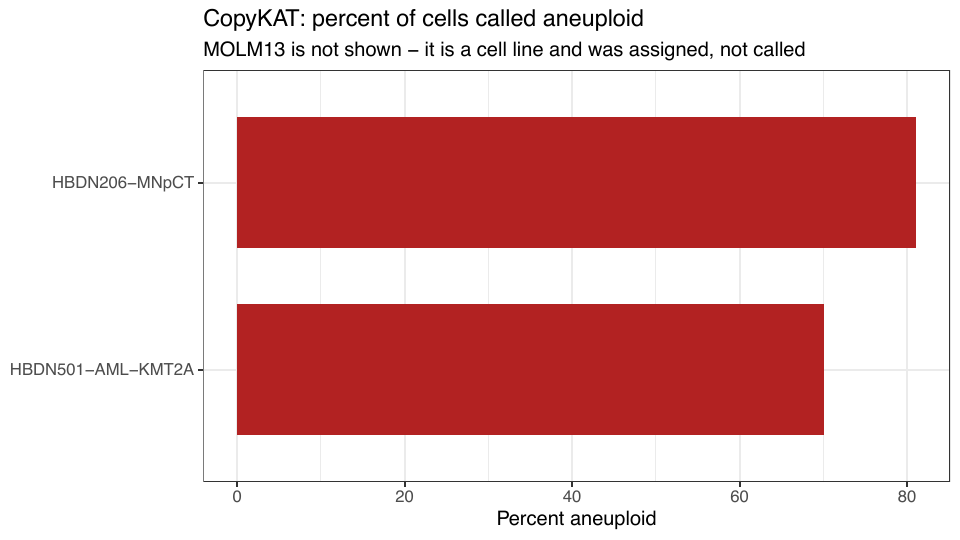

Numbat compartment per donor

| run_label | sample | numbat_compartment | n_cells | total | percent |
| --- | --- | --- | --- | --- | --- |
| LK1 | HBDN206-MNpCT | normal | 150 | 5981 | 2.51 |
| LK1 | HBDN206-MNpCT | not_called | 1428 | 5981 | 23.88 |
| LK1 | HBDN206-MNpCT | tumor | 4403 | 5981 | 73.62 |
| LK1 | HBDN392-AML-MDS | not_called | 6144 | 6144 | 100.00 |
| LK1 | HBDN501-AML-KMT2A | normal | 11 | 3154 | 0.35 |
| LK1 | HBDN501-AML-KMT2A | not_called | 1538 | 3154 | 48.76 |
| LK1 | HBDN501-AML-KMT2A | tumor | 1605 | 3154 | 50.89 |
| LK1 | MOLM13 | not_called | 6262 | 6262 | 100.00 |

Two donors come back entirely `not_called`. HBDN392-AML-MDS and MOLM13 did not produce usable Numbat output, so every Numbat statement in this report is based on HBDN206-MNpCT and HBDN501-AML-KMT2A only.

# 2. Do the two callers agree

Cell-level agreement, on cells with a call from both

| donor | n_cells | percent_agree | n_numbat_only | n_copykat_only |
| --- | --- | --- | --- | --- |
| HBDN206-MNpCT | 4409 | 96.35 | 152 | 9 |
| HBDN501-AML-KMT2A | 1488 | 94.96 | 73 | 2 |

**`02_copykat_vs_numbat_confusion.pdf`**

The off-diagonal is asymmetric. Numbat calling malignant where CopyKAT calls normal is much more common than the reverse.

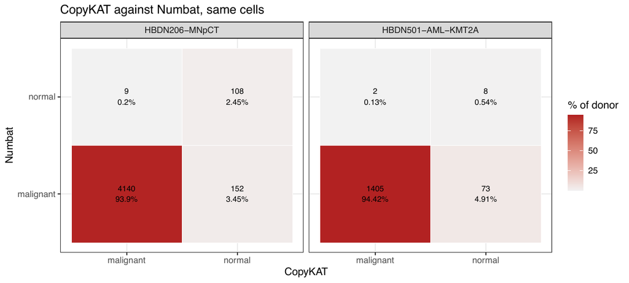

The headline number is high, and on its own it is misleading. Breaking agreement down by cell type shows where it actually comes from:

Agreement by broad cell type (populations with at least 20 cells)

| predicted_CellType_Broad | n_cells | percent_agree |
| --- | --- | --- |
| Naive T | 20 | 25.0 |
| B | 41 | 51.2 |
| Pro-Monocyte | 57 | 54.4 |
| CD4 Memory T | 43 | 62.8 |
| Monocyte | 490 | 75.9 |
| CD8 Memory T | 69 | 79.7 |
| Late GMP | 230 | 96.5 |
| HSC MPP | 4002 | 99.8 |
| Cycling Progenitor | 26 | 100.0 |
| Early GMP | 281 | 100.0 |
| EoBasoMast Precursor | 87 | 100.0 |
| LMPP | 255 | 100.0 |
| MEP | 226 | 100.0 |

HSC MPP is 4,002 of the 4,409 shared cells and agrees 99.8%, which is what drags the overall figure to 96%. The lymphoid populations - the ones the two callers actually have room to disagree about - sit between 25% and 80%.

This is worth being blunt about: **the lymphoid cells are CopyKAT’s normal reference.** CopyKAT was told they are diploid, so its calling them diploid is not independent evidence. Where Numbat calls some of those same cells malignant, the disagreement cannot be settled by this comparison - it is a question about whether the normal anchor was correctly chosen, and that is what step 05’s clone inspection is for.

# 3. What the callers do on a donor with no cancer

normal-01 in LK2 is a healthy donor. Anything called tumour there is a false positive, so it gives the floor that the AML numbers should be read against. Step 06 compares it against the three AML donors on the same per-cell CNV metrics.

Tumour-like fraction against the normal donor’s own distribution

| sample | group | metric | median | frac_above_normal_p99 | frac_above_normal_max |
| --- | --- | --- | --- | --- | --- |
| LK2_APOP576-TP53 | AML | cnv_z_abs_mean | 133.514 | 0.971 | 0.827 |
| LK2_HBDN376-TP53 | AML | cnv_z_abs_mean | 123.480 | 0.999 | 0.967 |
| LK2_HBDN498-TP53 | AML | cnv_z_abs_mean | 315.191 | 1.000 | 1.000 |
| LK2_normal-01 | Normal | cnv_z_abs_mean | 15.324 | 0.010 | 0.000 |
| LK2_APOP576-TP53 | AML | cnv_z_burden_100 | 0.538 | 0.990 | 0.990 |
| LK2_HBDN376-TP53 | AML | cnv_z_burden_100 | 0.500 | 0.991 | 0.991 |
| LK2_HBDN498-TP53 | AML | cnv_z_burden_100 | 0.810 | 1.000 | 1.000 |
| LK2_normal-01 | Normal | cnv_z_burden_100 | 0.000 | 0.000 | 0.000 |

**`02_fraction_above_normal_cnv_cutoffs.pdf`**

Fraction of each donor’s cells exceeding the normal donor’s cutoffs. The three AML donors sit at the top, normal-01 at the floor.

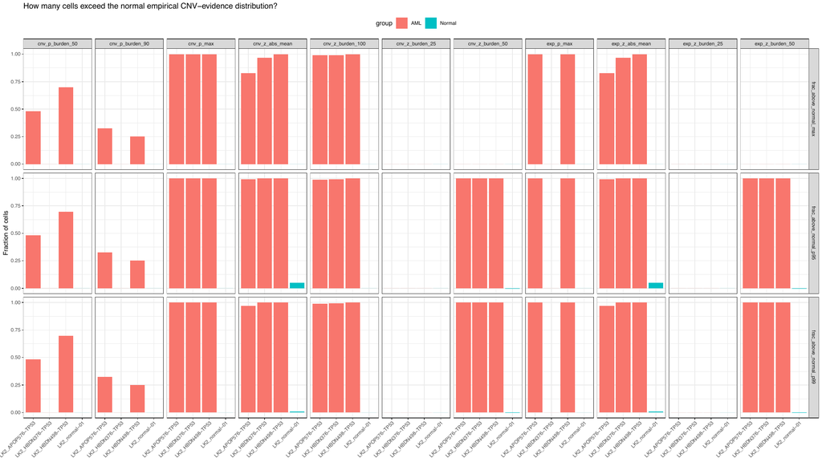

**`01_interpretable_per_cell_cnv_metrics.pdf`**

The per-cell metrics themselves, normal against AML.

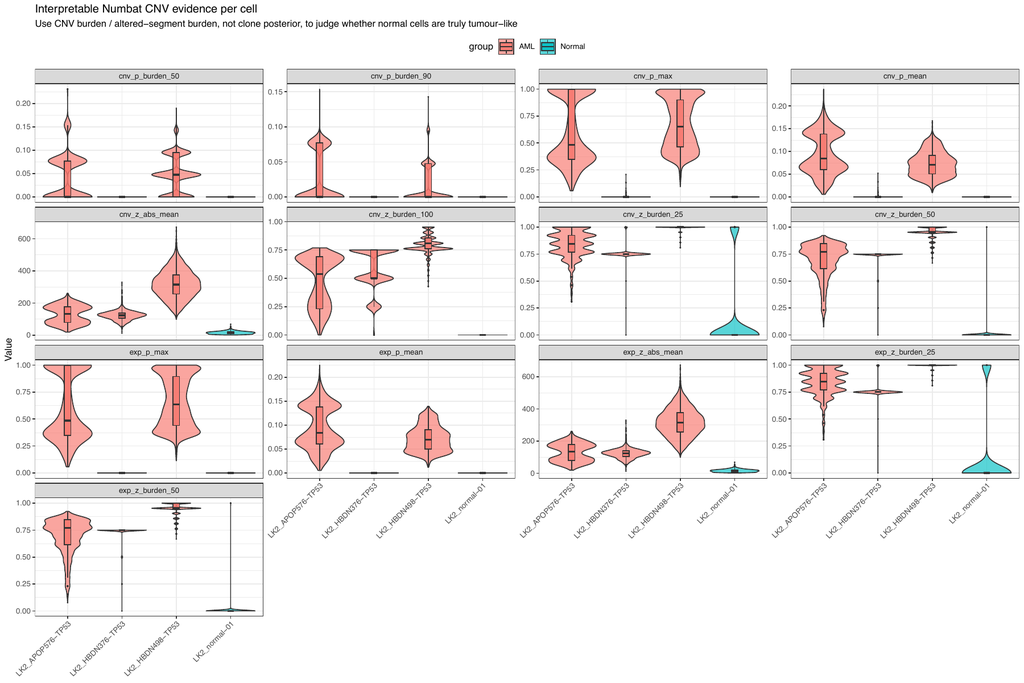

**`03_sample_level_evidence.pdf`**

Sample-level CNV evidence.

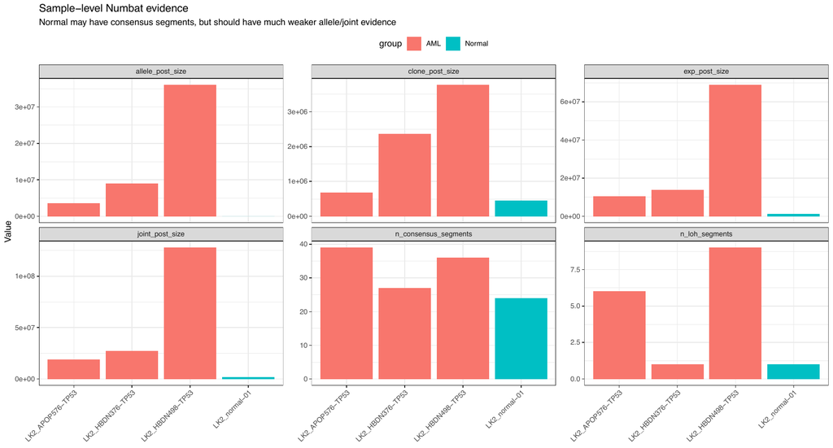

The separation is clean. Median `cnv_z_abs_mean` is 15.3 in normal-01 against 123, 133 and 315 in the AML donors, and 1.0% of normal cells exceed the normal 99th percentile against 97-100% of AML cells. Numbat is not manufacturing cancer out of a healthy marrow.

# 4. Short read against long read

The same LK2 cells were sequenced on both platforms and Numbat was run on each. Same donors, same barcodes, same caller - so any disagreement is the data, not the method.

Short read against long read, per donor

| donor | n_cells | sr_percent_tumor | lr_percent_tumor | compartment_concordance | pcnv_correlation | sr_tumor_lr_normal | sr_normal_lr_tumor |
| --- | --- | --- | --- | --- | --- | --- | --- |
| LK2_HBDN498-TP53 | 5790 | 99.81 | 93.96 | 94.15 | 0.189 | 339 | 0 |
| LK2_HBDN376-TP53 | 6343 | 95.84 | 88.48 | 89.52 | 0.413 | 566 | 99 |
| LK2_APOP576-TP53 | 1008 | 98.91 | 62.90 | 63.59 | 0.122 | 365 | 2 |

**`03_shortread_vs_longread_tumor_fraction.pdf`**

Long read calls fewer cells tumour in every donor.

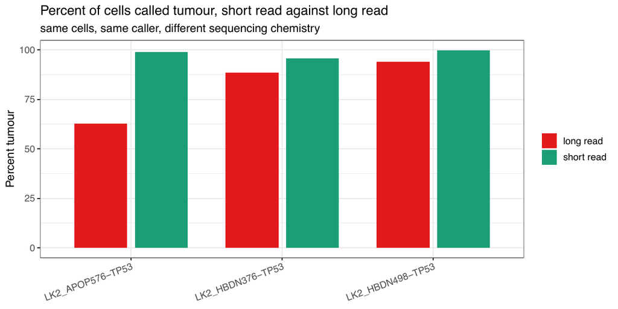

**`04_shortread_vs_longread_direction.pdf`**

The disagreement is almost entirely one-directional. Cells that short read calls tumour and long read calls normal outnumber the reverse by orders of magnitude in two of the three donors.

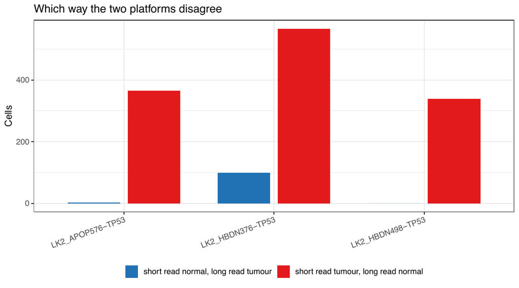

Two numbers should be read together here. Compartment concordance looks respectable at 89-94% for two of the donors, but the per-cell pCNV correlation is 0.12-0.41. The platforms put cells in the same bin without agreeing on the evidence behind it, which means the compartment call is robust in a way the per-cell CNV probability is not. Anything downstream that uses pCNV as a continuous quantity should not be trusted across platforms.

APOP576-TP53 is the worst on both counts - 63.6% concordance and 0.12 correlation. It is also the sample that loses 30% of its cells to BoneMarrowMap mapping-error QC in the annotation benchmark. The same sample being the outlier in two unrelated analyses points at the sample rather than at either method.

**`summary_broad_lineage_composition_overlap.pdf`**

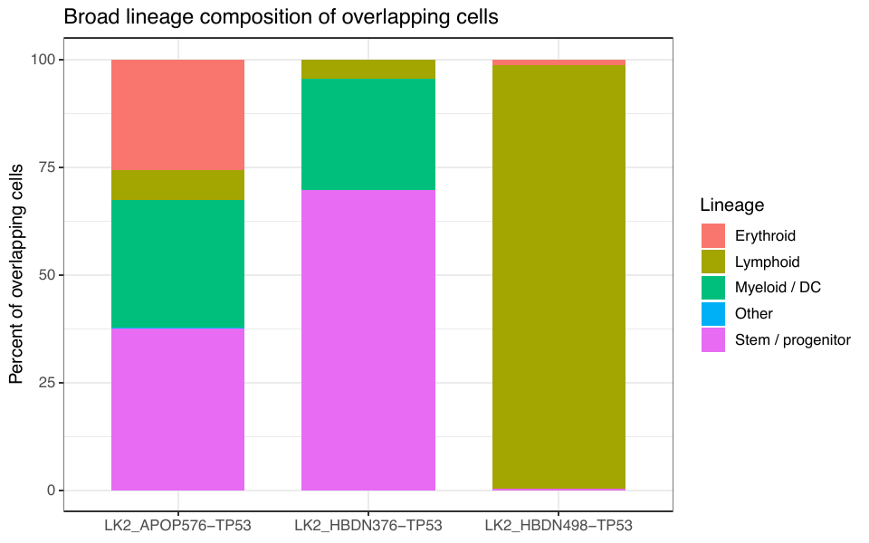

**`summary_compartment_alluvial_all.pdf`**

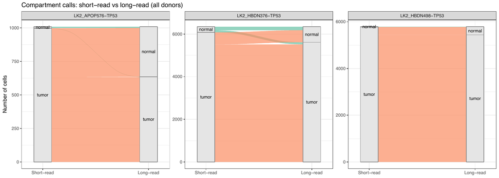

**`summary_compartment_concordance.pdf`**

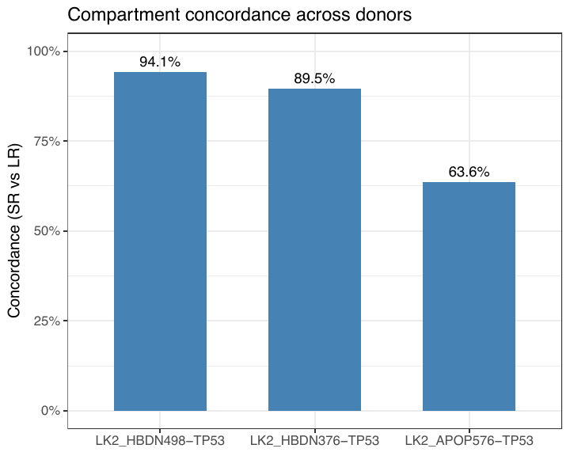

**`summary_compartment_switches.pdf`**

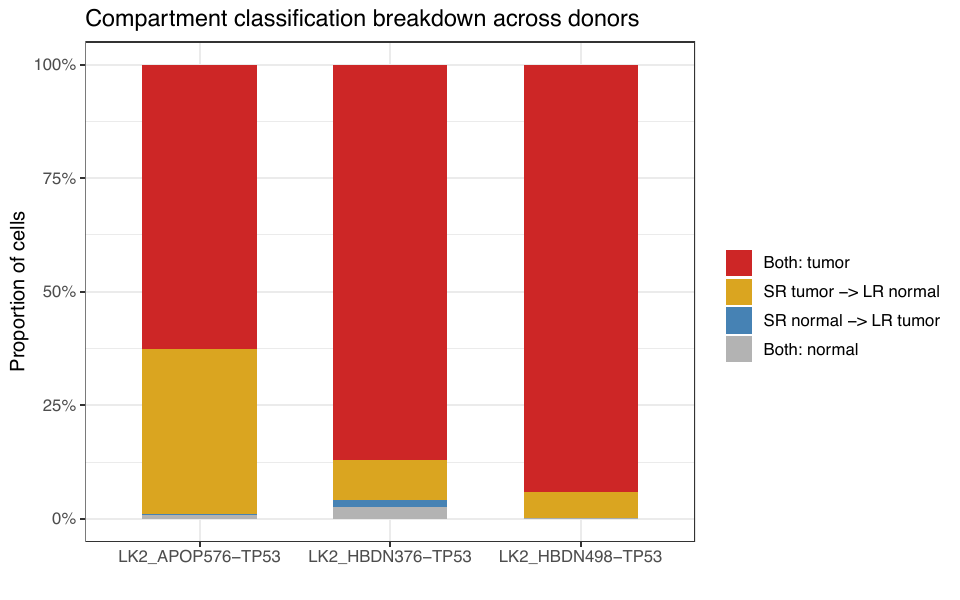

**`summary_pCNV_density_by_switch.pdf`**

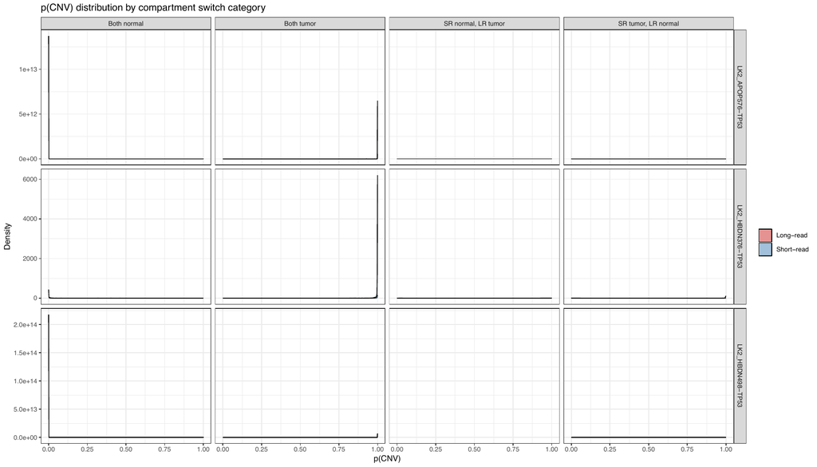

**`summary_pCNV_scatter_all.pdf`**

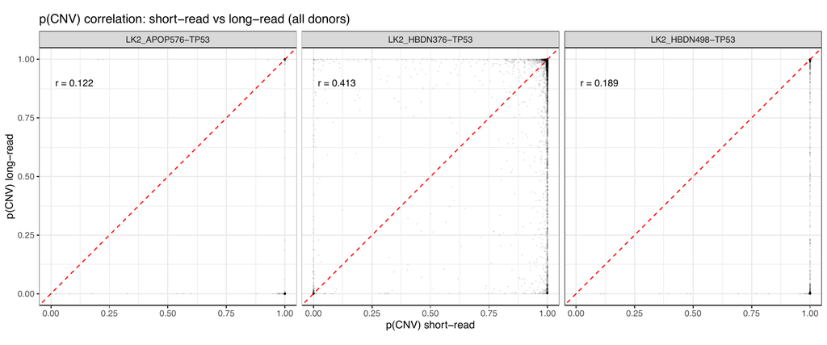

**`summary_total_tumor_normal_counts.pdf`**

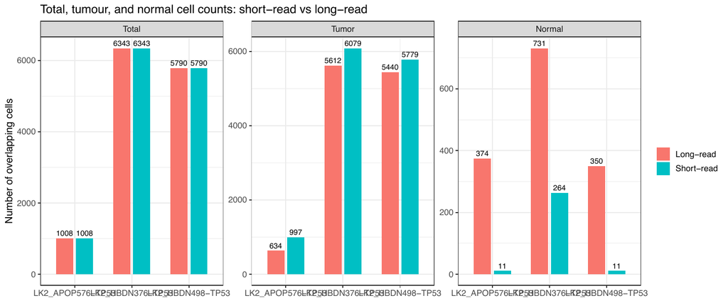

**`summary_tumor_counts.pdf`**

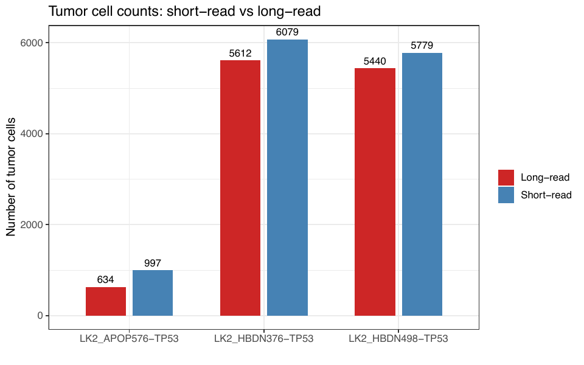

# 5. Per-donor detail

**`LK2_APOP576-TP53_broad_lineage_composition_by_compartment.pdf`**

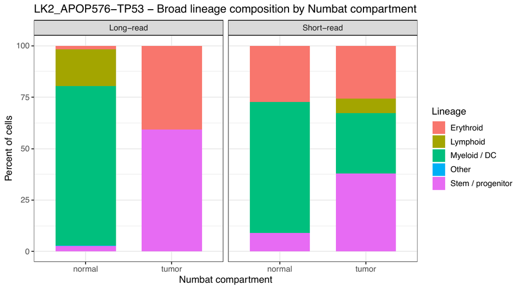

**`LK2_APOP576-TP53_clone_alluvial.pdf`**

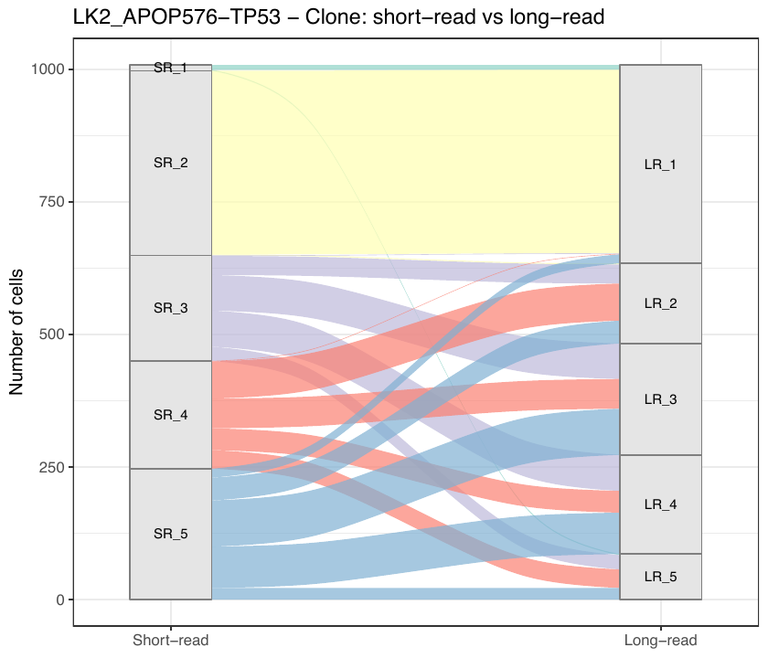

**`LK2_APOP576-TP53_clone_correlation_heatmap.pdf`**

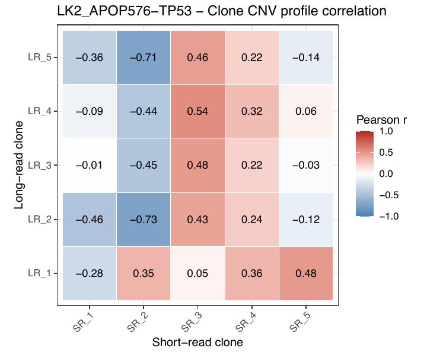

**`LK2_APOP576-TP53_clone_matched_alluvial.pdf`**

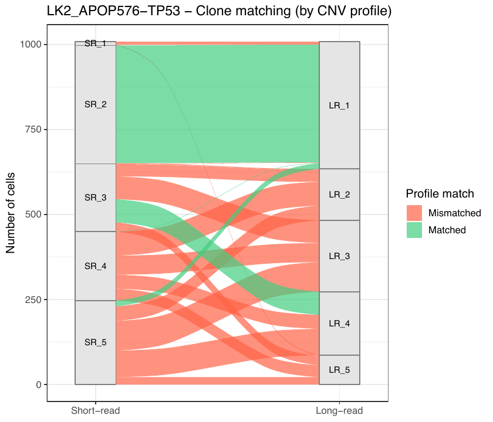

**`LK2_APOP576-TP53_compartment_alluvial.pdf`**

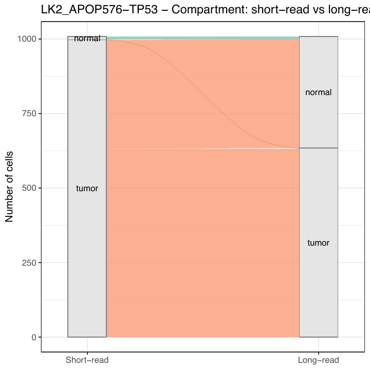

**`LK2_APOP576-TP53_pCNV_scatter.pdf`**

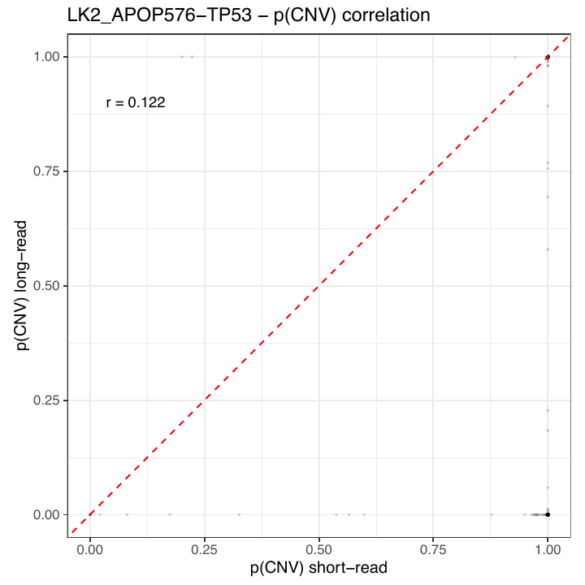

**`LK2_APOP576-TP53_segments_comparison.pdf`**

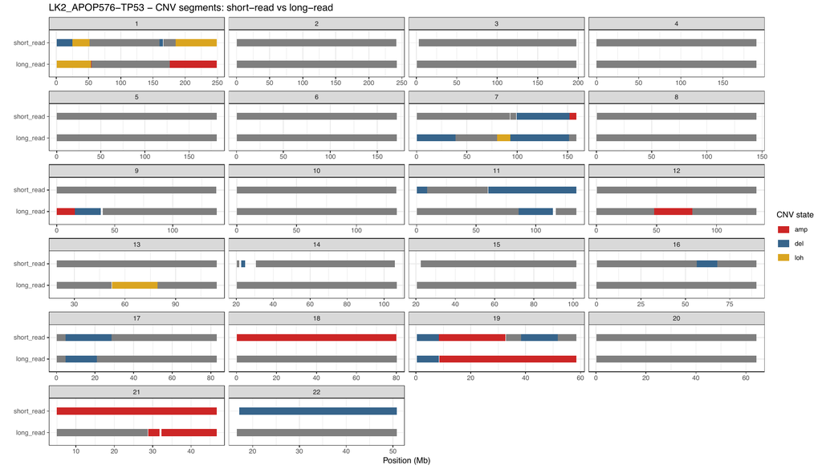

**`LK2_HBDN376-TP53_broad_lineage_composition_by_compartment.pdf`**

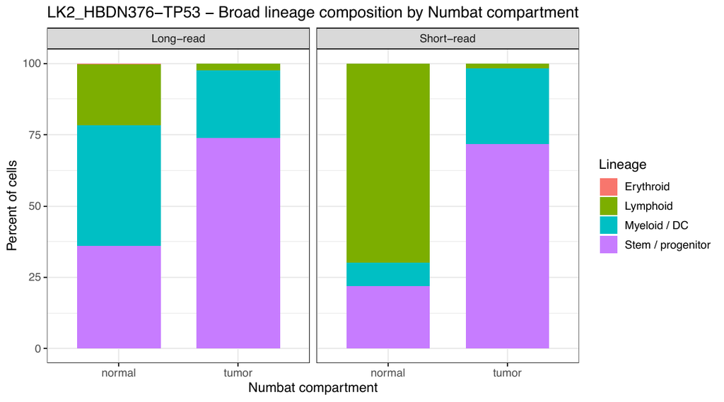

**`LK2_HBDN376-TP53_clone_alluvial.pdf`**

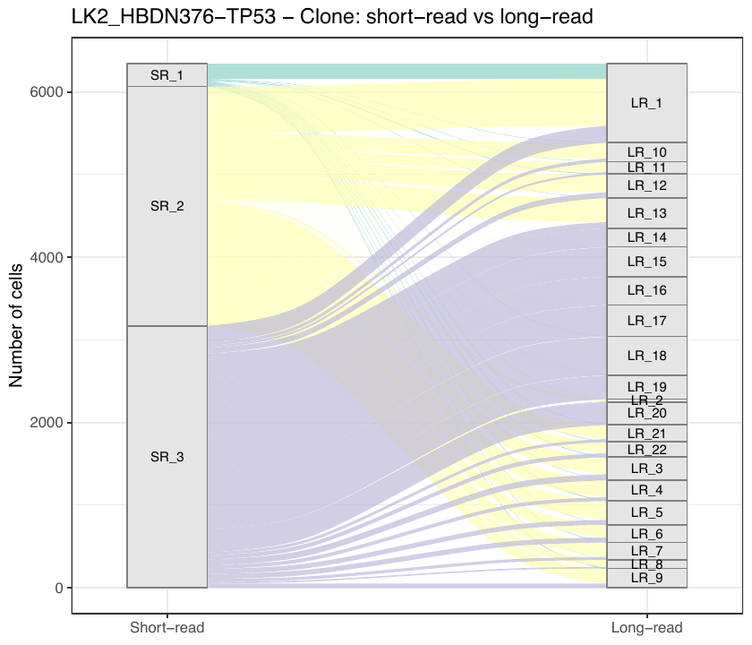

**`LK2_HBDN376-TP53_compartment_alluvial.pdf`**

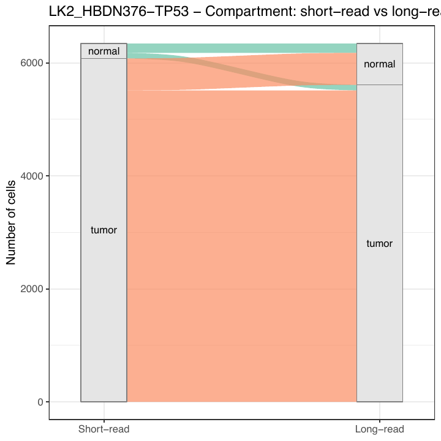

**`LK2_HBDN376-TP53_pCNV_scatter.pdf`**

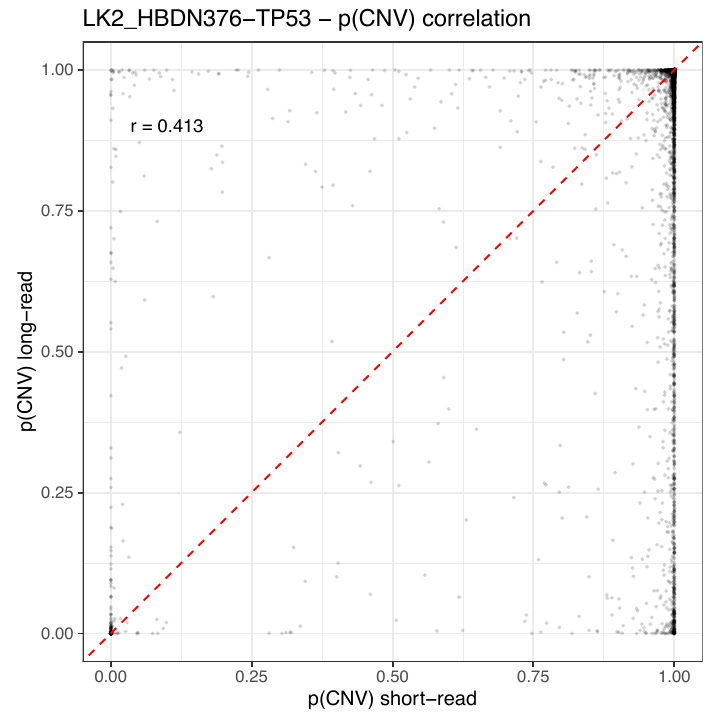

**`LK2_HBDN376-TP53_segments_comparison.pdf`**

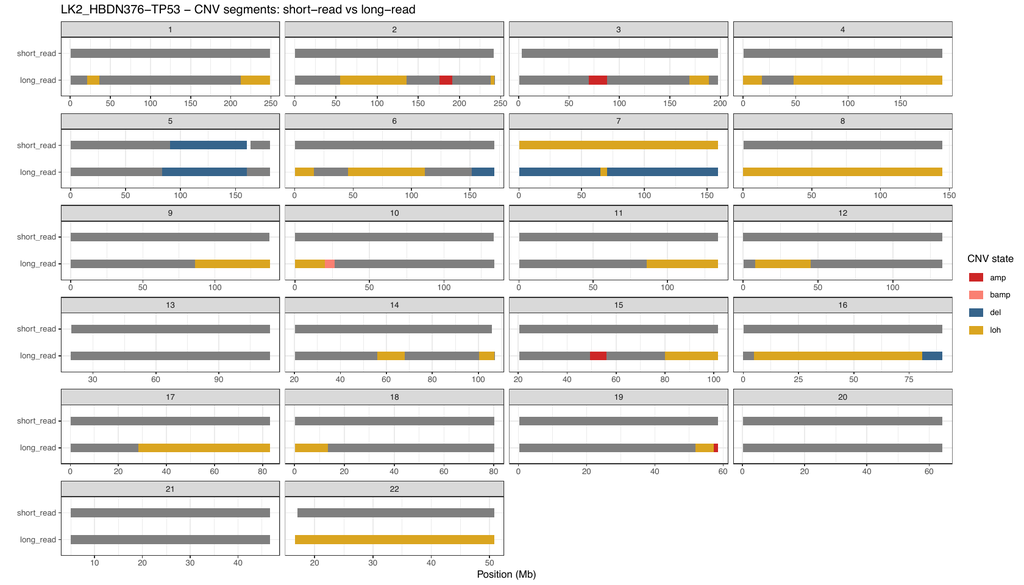

**`LK2_HBDN498-TP53_broad_lineage_composition_by_compartment.pdf`**

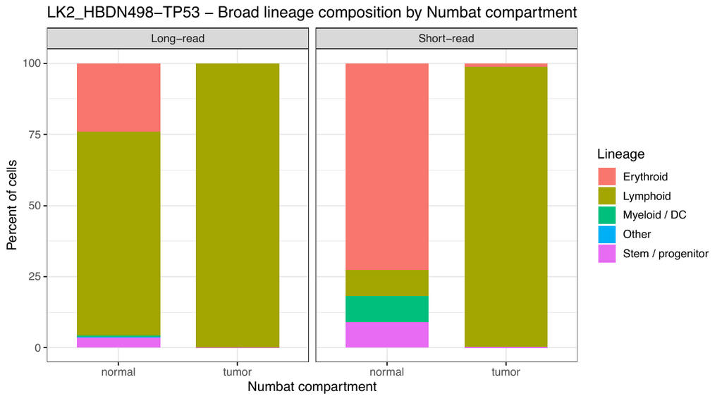

**`LK2_HBDN498-TP53_clone_alluvial.pdf`**

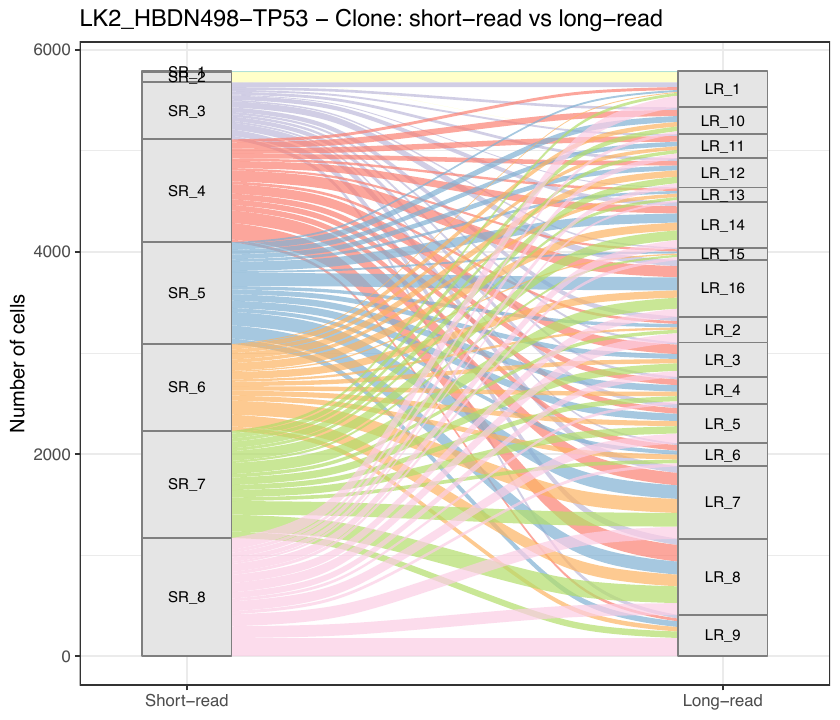

**`LK2_HBDN498-TP53_clone_correlation_heatmap.pdf`**